# proj3_Chen

Weixuan Chen

4/14/2023

## Problem 1

## Data Preparation

```r
benguela <- read.csv("http://faraway.neu.edu/biostats/assn3_benguela.csv")
california <- read.csv("http://faraway.neu.edu/biostats/assn3_california.csv")
canary <- read.csv("http://faraway.neu.edu/biostats/assn3_canary.csv")
humboldt <- read.csv("http://faraway.neu.edu/biostats/assn3_humboldt.csv")
```

```r
benguela
```

```
##      model1  model2  model3  model4  model5  model6  model7  model8  model9
## 1   0.64846 0.84749 0.31267 0.57551 0.82089 1.00640 0.96211 1.39690 1.07800
## 2   0.72179 0.88562 0.70475 0.60674 0.86197 1.07100 0.81461 1.34060 1.00340
## 3   0.68546 0.92245 0.66867 0.59140 0.92522 1.03370 0.70644 1.29460 0.84494
## 4   0.87767 0.87275 0.64534 0.59515 0.86161 0.79521 0.75749 1.28020 0.98820
## 5   0.69272 0.89956 0.39448 0.64885 0.78472 1.08320 0.87162 1.36810 1.04590
## 6   0.69628 0.86322 0.42740 0.56471 0.85227 0.96836 0.82824 1.09900 0.69756
## 7   0.95588 0.69684 0.43676 0.58938 0.74973 0.98347 0.99148 1.33520 0.77937
## 8   0.66861 1.03990 0.41801 0.55874 1.00280 0.79127 1.05900 1.17670 0.85753
## 9   0.66955 0.72037 0.58152 0.72403 0.78099 0.86316 1.01890 0.81387 1.04160
## 10  0.88869 1.00460 0.39903 0.46885 0.76636 0.92608 0.96582 1.54850 1.05020
## 11  0.77763 0.80039 0.57298 0.63065 0.93047 0.96476 1.04010 1.11350 1.10530
## 12  0.79890 0.80349 0.31681 0.54331 0.64584 0.97087 0.96913 1.02530 0.97908
## 13  0.64733 0.70746 0.54661 0.77331 0.83844 0.82563 0.97456 1.08800 0.86674
## 14  0.77537 0.83299 0.32967 0.53693 0.96196 0.99822 0.96650 0.98604 1.08430
```

[output cut: 438 more lines]

## 1

```r
california$period <- ifelse(california$year >= 1950 & california$year <= 2024, "before", "after")
benguela$period <- ifelse(benguela$year >= 1950 & benguela$year <= 2024, "before", "after")
canary$period <- ifelse(canary$year >= 1950 & canary$year <= 2024, "before", "after")
humboldt$period <- ifelse(humboldt$year >= 1950 & humboldt$year <= 2024, "before", "after")
```

## 2

```r
# Multimodel mean for California
california.mean <- data.frame(year=california$year,
period=california$period,
upwelling= rowMeans(california[,1:22]))

# Multimodel mean for Canary
canary.mean <- data.frame(year=canary$year,
period=canary$period,
upwelling=rowMeans(canary[,1:22]))

# Multimodel mean for Humboldt
humboldt.mean <- data.frame(year=humboldt$year,
period=humboldt$period,
upwelling=rowMeans(humboldt[,1:22]))

# Multimodel mean for Benguela
benguela.mean <- data.frame(year=benguela$year,
period=benguela$period,
upwelling=rowMeans(benguela[,1:22]))
```

```r
california.mean
```

```
##     year period upwelling
## 1   1950 before 0.3417591
## 2   1951 before 0.3191518
## 3   1952 before 0.3469232
## 4   1953 before 0.3398432
## 5   1954 before 0.3459844
## 6   1955 before 0.3287795
## 7   1956 before 0.3334814
## 8   1957 before 0.3150314
## 9   1958 before 0.3490642
## 10  1959 before 0.3629041
## 11  1960 before 0.3254918
## 12  1961 before 0.3289655
## 13  1962 before 0.3401118
## 14  1963 before 0.3494630
```

[output cut: 136 more lines]

## 3

I am using Shapiro Wilk’s Normality Test, and I have 8 tests to do.. H0: The data is from the normal distribution H1: The data is not from the normal distribution

```r
california.mean.before <- subset(california.mean, period == "before")
california.mean.after <- subset(california.mean, period == "after")
```

```r
shapiro.test(california.mean.before$upwelling)
```

```
##
##  Shapiro-Wilk normality test
##
## data:  california.mean.before$upwelling
## W = 0.98943, p-value = 0.7929
```

```r
shapiro.test(california.mean.after$upwelling)
```

```
##
##  Shapiro-Wilk normality test
##
## data:  california.mean.after$upwelling
## W = 0.97638, p-value = 0.1737
```

For this two datasets, we can see the p-values are above 0.05 level. Therefore, we don’t have enough evidence to reject the null hypothesis and we can assume the normality.

```r
canary.mean.before <- subset(canary.mean, period == "before")
canary.mean.after <- subset(canary.mean, period == "after")
```

```r
shapiro.test(canary.mean.before$upwelling)
```

```
##
##  Shapiro-Wilk normality test
##
## data:  canary.mean.before$upwelling
## W = 0.98603, p-value = 0.5817
```

```r
shapiro.test(canary.mean.after$upwelling)
```

```
##
##  Shapiro-Wilk normality test
##
## data:  canary.mean.after$upwelling
## W = 0.96229, p-value = 0.02496
```

```r
humboldt.mean.before <- subset(humboldt.mean, period == "before")
humboldt.mean.after <- subset(humboldt.mean, period == "after")
```

```r
shapiro.test(humboldt.mean.before$upwelling)
```

```
##
##  Shapiro-Wilk normality test
##
## data:  humboldt.mean.before$upwelling
## W = 0.9877, p-value = 0.6858
```

```r
shapiro.test(humboldt.mean.after$upwelling)
```

```
##
##  Shapiro-Wilk normality test
##
## data:  humboldt.mean.after$upwelling
## W = 0.96227, p-value = 0.02489
```

```r
benguela.mean.before <- subset(benguela.mean, period == "before")
benguela.mean.after <- subset(benguela.mean, period == "after")
```

```r
shapiro.test(benguela.mean.before$upwelling)
```

```
##
##  Shapiro-Wilk normality test
##
## data:  benguela.mean.before$upwelling
## W = 0.98281, p-value = 0.4028
```

```r
shapiro.test(benguela.mean.after$upwelling)
```

```
##
##  Shapiro-Wilk normality test
##
## data:  benguela.mean.after$upwelling
## W = 0.98991, p-value = 0.8204
```

For this two datasets, we can see the p-values are above 0.05 level. Therefore, we don’t have enough evidence to reject the null hypothesis and we can assume the normality.

Since we observe the non-normality in two groups of data, we can use non-parametric tests for the comparisons. Using non-parametric tests will focus on the median of the data instead of mean. We probably don’t want to use the median because we want to compare the means between groups. Therefore, we can use non-parametric tests on groups with non-normal data and parametric test on groups with normal data.

## 4

unpaired two-sample t-test H0: there is no difference between means H1: there is difference between means

unpaired two-sample Wilcoxon test H0: the observation of $\mu_1-\mu_2$ is symmetric about 0 H1: the observation of $\mu_1-\mu_2$ is not symmetric about 0

```r
t.test(california.mean.before$upwelling, california.mean.after$upwelling, alternative = "two.sided", var.equal = FALSE)
```

```
##
##  Welch Two Sample t-test
##
## data:  california.mean.before$upwelling and california.mean.after$upwelling
## t = -4.1992, df = 141.1, p-value = 4.72e-05
## alternative hypothesis: true difference in means is not equal to 0
## 95 percent confidence interval:
##  -0.014628447 -0.005263617
## sample estimates:
## mean of x mean of y
## 0.3415715 0.3515175
```

```r
t.test(benguela.mean.before$upwelling, benguela.mean.after$upwelling, alternative = "two.sided", var.equal = FALSE)
```

```
##
##  Welch Two Sample t-test
##
## data:  benguela.mean.before$upwelling and benguela.mean.after$upwelling
## t = -14.086, df = 147.56, p-value < 2.2e-16
## alternative hypothesis: true difference in means is not equal to 0
## 95 percent confidence interval:
##  -0.10870602 -0.08195718
## sample estimates:
## mean of x mean of y
## 0.8206088 0.9159404
```

```r
wilcox.test(canary.mean.before$upwelling, canary.mean.after$upwelling, alternative = "two.sided")
```

```
##
##  Wilcoxon rank sum test with continuity correction
##
## data:  canary.mean.before$upwelling and canary.mean.after$upwelling
## W = 162, p-value < 2.2e-16
## alternative hypothesis: true location shift is not equal to 0
```

```r
wilcox.test(humboldt.mean.before$upwelling, humboldt.mean.after$upwelling, alternative = "two.sided")
```

```
##
##  Wilcoxon rank sum test with continuity correction
##
## data:  humboldt.mean.before$upwelling and humboldt.mean.after$upwelling
## W = 276, p-value < 2.2e-16
## alternative hypothesis: true location shift is not equal to 0
```

These four tests all have p-values that are less than 0.05 level. We can reject the null hypothesis and conclude that there is difference between the means of groups.

## 5

```r
# Compute group means and stderrs for California
mean.upwelling.california <- aggregate(upwelling ~ period, FUN=mean, data=california.mean)
sderr.upwelling.california <- aggregate(upwelling ~ period,
FUN=function (x) sd(x),
data=california.mean)

# Compute group means and stderrs for Canary
mean.upwelling.canary <- aggregate(upwelling ~ period, FUN=mean, data=canary.mean)
sderr.upwelling.canary <- aggregate(upwelling ~ period,
FUN=function (x) sd(x),
data=canary.mean)

# Compute group means and stderrs for Humboldt
mean.upwelling.humboldt <- aggregate(upwelling ~ period, FUN=mean, data=humboldt.mean)
sderr.upwelling.humboldt <- aggregate(upwelling ~ period,
FUN=function (x) sd(x),
data=humboldt.mean)

# Compute group means and stderrs for Benguela
mean.upwelling.benguela <- aggregate(upwelling ~ period, FUN=mean, data=benguela.mean)
sderr.upwelling.benguela <- aggregate(upwelling ~ period,
FUN=function (x) sd(x),
data=benguela.mean)
```

## 6

```r
# Combine data into a single means dataframe
upwelling.mean <- data.frame(region=c("Canary", "California", "Benguela", "Humboldt"),

after=c(mean.upwelling.canary$upwelling[2],
mean.upwelling.california$upwelling[2],
mean.upwelling.benguela$upwelling[2],
mean.upwelling.humboldt$upwelling[2]),
before=c(mean.upwelling.canary$upwelling[1],
mean.upwelling.california$upwelling[1],
mean.upwelling.benguela$upwelling[1],
mean.upwelling.humboldt$upwelling[1]))

# Combine data into a single stderrs dataframe
upwelling.sderr <- data.frame(region=c("Canary", "California", "Benguela", "Humboldt"),

after=c(sderr.upwelling.canary$upwelling[2],
sderr.upwelling.california$upwelling[2],
sderr.upwelling.benguela$upwelling[2],
sderr.upwelling.humboldt$upwelling[2]),
before=c(sderr.upwelling.canary$upwelling[1],
sderr.upwelling.california$upwelling[1],
sderr.upwelling.benguela$upwelling[1],
sderr.upwelling.humboldt$upwelling[1]))
```

```r
upwelling.mean
```

```
##       region     after    before
## 1     Canary 0.4721527 0.5670722
## 2 California 0.3415715 0.3515175
## 3   Benguela 0.8206088 0.9159404
## 4   Humboldt 0.3717131 0.4732848
```

```r
upwelling.sderr
```

```
##       region      after     before
## 1     Canary 0.02869083 0.03813852
## 2 California 0.01602744 0.01280118
## 3   Benguela 0.04255854 0.04029952
## 4   Humboldt 0.04028269 0.04827068
```

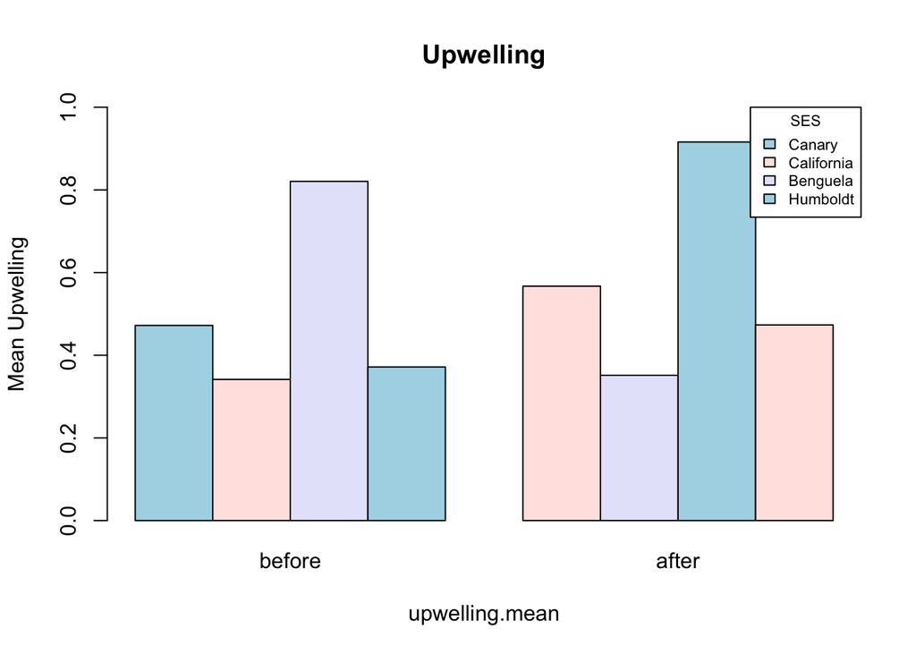

```r
bp <- barplot(as.matrix(upwelling.mean[, 2:3]), beside = TRUE, main = "Upwelling",
col = c("lightblue", "mistyrose", "lavender"),
xlab = "upwelling.mean", names = c("before", "after"),
ylab = "Mean Upwelling", legend = c("Canary", "California", "Benguela", "Humboldt"),
args.legend = list(title = "SES", x = "topright", cex = .7), ylim = c(0, 1))
```

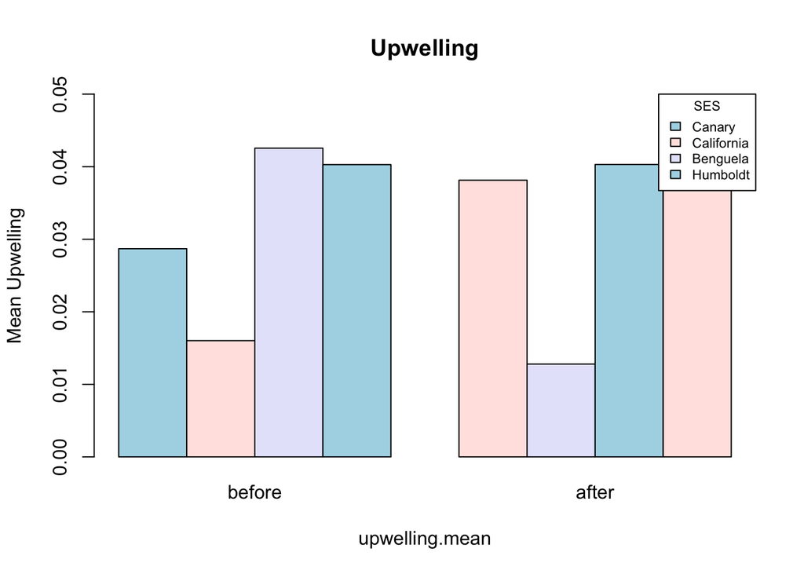

```r
bp <- barplot(as.matrix(upwelling.sderr[, 2:3]), beside = TRUE, main = "Upwelling",
col = c("lightblue", "mistyrose", "lavender"),
xlab = "upwelling.mean", names = c("before", "after"),
ylab = "Mean Upwelling", legend = c("Canary", "California", "Benguela", "Humboldt"),
args.legend = list(title = "SES", x = "topright", cex = .7), ylim = c(0, 0.05))
```

## 7

Given the plots and statistical analysis, we can see an increasing trend in multimodel means.

## 8

We can use F-test for equality of variances or Levene’s test for equality of variances. F-test assumes the distribution of data is normal, while Levene’s test does not. Levene’s test is more robust than F-test.

## 9

H0: The variances of two groups are equal H1: The variances of two groups are not equal

```r
var.test(upwelling ~ period, california.mean, alternative = "two.sided")
```

```
##
##  F test to compare two variances
##
## data:  upwelling by period
## F = 0.63793, num df = 74, denom df = 74, p-value = 0.05499
## alternative hypothesis: true ratio of variances is not equal to 1
## 95 percent confidence interval:
##  0.4030312 1.0097286
## sample estimates:
## ratio of variances
##           0.637928
```

```r
var.test(upwelling ~ period, benguela.mean, alternative = "two.sided")
```

```
##
##  F test to compare two variances
##
## data:  upwelling by period
## F = 0.89666, num df = 74, denom df = 74, p-value = 0.6402
## alternative hypothesis: true ratio of variances is not equal to 1
## 95 percent confidence interval:
##  0.5664913 1.4192513
## sample estimates:
## ratio of variances
##          0.8966569
```

```r
library(lawstat)
```

```r
levene.test(canary.mean$upwelling, canary.mean$period, location="median", correction.method="zero.correction")
```

```
##
##  Modified robust Brown-Forsythe Levene-type test based on the absolute
##  deviations from the median with modified structural zero removal method
##  and correction factor
##
## data:  canary.mean$upwelling
## Test Statistic = 6.774, p-value = 0.0102
```

```r
levene.test(humboldt.mean$upwelling, humboldt.mean$period, location="median", correction.method="zero.correction")
```

```
##
##  Modified robust Brown-Forsythe Levene-type test based on the absolute
##  deviations from the median with modified structural zero removal method
##  and correction factor
##
## data:  humboldt.mean$upwelling
## Test Statistic = 5.547, p-value = 0.01984
```

## Problem 2

## 1

We can perform linear regression to check the rate of change, which is indicated by slope. We can use upwelling as response variable and year as explanatory variable to see the trend over time.

## 2

1. At each value of X, there is a population of possible Y-values whose mean lies on the true regression line (also therefore assumes a linear relationship between X and Y)
2. At each value of X, the distribution of Y is normal
3. The variance of Y values is the same at each value of X
4. At each value of X, the Y measurements are a random sample from the population of possible Y-values

The california and benguela systems meet the requirements while the other two do not.

```r
lm_california = lm(upwelling~year, data = california.mean) #Create the linear regression
summary(lm_california) #Review the results
```

```
##
## Call:
## lm(formula = upwelling ~ year, data = california.mean)
##
## Residuals:
##       Min        1Q    Median        3Q       Max
## -0.038587 -0.009693 -0.000679  0.008362  0.040669
##
## Coefficients:
##              Estimate Std. Error t value Pr(>|t|)
## (Intercept) 1.040e-01  5.509e-02   1.887   0.0611 .
## year        1.198e-04  2.721e-05   4.404 2.02e-05 ***
## ---
## Signif. codes:  0 '***' 0.001 '**' 0.01 '*' 0.05 '.' 0.1 ' ' 1
##
## Residual standard error: 0.01443 on 148 degrees of freedom
## Multiple R-squared:  0.1159, Adjusted R-squared:  0.1099
## F-statistic:  19.4 on 1 and 148 DF,  p-value: 2.023e-05
```

```r
lm_benguela = lm(upwelling~year, data = benguela.mean) #Create the linear regression
summary(lm_benguela) #Review the results
```

```
##
## Call:
## lm(formula = upwelling ~ year, data = benguela.mean)
##
## Residuals:
##       Min        1Q    Median        3Q       Max
## -0.053242 -0.019020  0.001129  0.017508  0.083227
##
## Coefficients:
##               Estimate Std. Error t value Pr(>|t|)
## (Intercept) -1.796e+00  1.031e-01  -17.41   <2e-16 ***
## year         1.316e-03  5.093e-05   25.84   <2e-16 ***
## ---
## Signif. codes:  0 '***' 0.001 '**' 0.01 '*' 0.05 '.' 0.1 ' ' 1
##
## Residual standard error: 0.02701 on 148 degrees of freedom
## Multiple R-squared:  0.8185, Adjusted R-squared:  0.8173
## F-statistic: 667.6 on 1 and 148 DF,  p-value: < 2.2e-16
```

```r
lm_canary = lm(upwelling~year, data = canary.mean) #Create the linear regression
summary(lm_canary) #Review the results
```

```
##
## Call:
## lm(formula = upwelling ~ year, data = canary.mean)
##
## Residuals:
##       Min        1Q    Median        3Q       Max
## -0.066392 -0.016333 -0.001149  0.016434  0.065723
##
## Coefficients:
##               Estimate Std. Error t value Pr(>|t|)
## (Intercept) -1.9472689  0.0935523  -20.82   <2e-16 ***
## year         0.0012185  0.0000462   26.38   <2e-16 ***
## ---
## Signif. codes:  0 '***' 0.001 '**' 0.01 '*' 0.05 '.' 0.1 ' ' 1
##
## Residual standard error: 0.0245 on 148 degrees of freedom
## Multiple R-squared:  0.8246, Adjusted R-squared:  0.8234
## F-statistic: 695.6 on 1 and 148 DF,  p-value: < 2.2e-16
```

```r
lm_humboldt = lm(upwelling~year, data = humboldt.mean) #Create the linear regression
summary(lm_humboldt) #Review the results
```

```
##
## Call:
## lm(formula = upwelling ~ year, data = humboldt.mean)
##
## Residuals:
##       Min        1Q    Median        3Q       Max
## -0.101277 -0.014199  0.000978  0.017080  0.075162
##
## Coefficients:
##               Estimate Std. Error t value Pr(>|t|)
## (Intercept) -2.472e+00  1.015e-01  -24.35   <2e-16 ***
## year         1.430e-03  5.013e-05   28.52   <2e-16 ***
## ---
## Signif. codes:  0 '***' 0.001 '**' 0.01 '*' 0.05 '.' 0.1 ' ' 1
##
## Residual standard error: 0.02659 on 148 degrees of freedom
## Multiple R-squared:  0.846,  Adjusted R-squared:  0.845
## F-statistic: 813.2 on 1 and 148 DF,  p-value: < 2.2e-16
```

## 3

```r
california.mean.train <- california.mean[,c("year","upwelling")]
benguela.mean.train <- benguela.mean[,c("year","upwelling")]
canary.mean.train <- canary.mean[,c("year","upwelling")]
humboldt.mean.train <- humboldt.mean[,c("year","upwelling")]
```

```r
california.pred <- predict(lm_california, newdata = california.mean.train)
benguela.pred <- predict(lm_benguela, newdata = benguela.mean.train)
canary.pred <- predict(lm_canary, newdata = canary.mean.train)
humboldt.pred <- predict(lm_humboldt, newdata = humboldt.mean.train)
```

```r
a <- as.data.frame(california.pred)
a["b.pred"] <- benguela.pred
a["c.pred"] <- canary.pred
a["h.pred"] <- humboldt.pred
a["year"] <- california.mean$year
```

```r
a
```

```
##     california.pred    b.pred    c.pred    h.pred year
## 1         0.3376176 0.7702345 0.4288332 0.3159946 1950
## 2         0.3377374 0.7715505 0.4300517 0.3174242 1951
## 3         0.3378572 0.7728665 0.4312702 0.3188538 1952
## 4         0.3379770 0.7741825 0.4324887 0.3202834 1953
## 5         0.3380969 0.7754984 0.4337072 0.3217130 1954
## 6         0.3382167 0.7768144 0.4349257 0.3231425 1955
## 7         0.3383365 0.7781304 0.4361443 0.3245721 1956
## 8         0.3384563 0.7794464 0.4373628 0.3260017 1957
## 9         0.3385762 0.7807623 0.4385813 0.3274313 1958
## 10        0.3386960 0.7820783 0.4397998 0.3288609 1959
## 11        0.3388158 0.7833943 0.4410183 0.3302905 1960
## 12        0.3389356 0.7847103 0.4422368 0.3317201 1961
## 13        0.3390555 0.7860262 0.4434553 0.3331497 1962
## 14        0.3391753 0.7873422 0.4446739 0.3345792 1963
```

[output cut: 136 more lines]

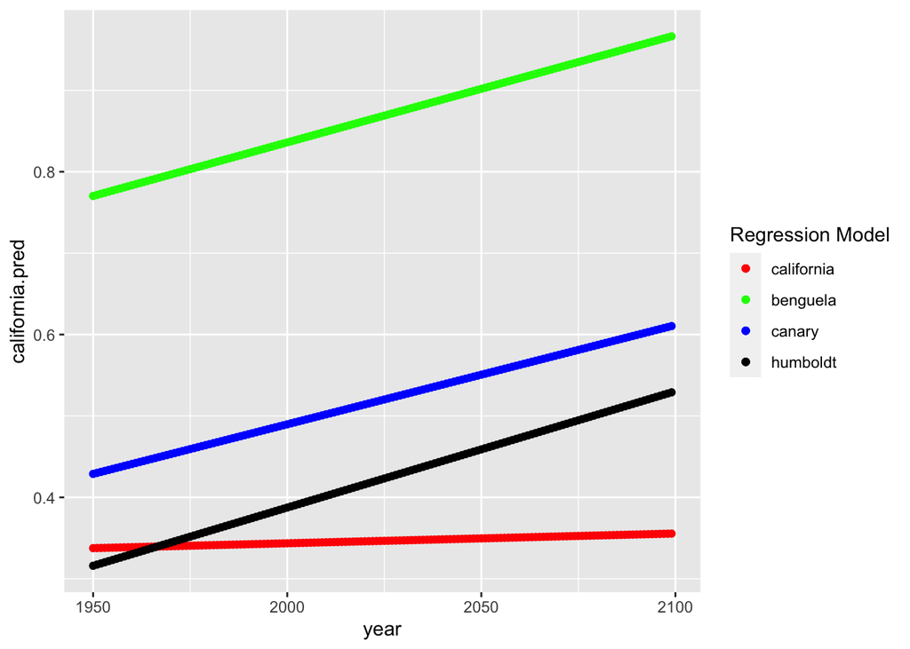

```r
library(ggplot2)
ggplot(a, aes(x = year)) +
    geom_point(aes(y = california.pred, color = "california")) +
    geom_point(aes(y = b.pred, color = "benguela"))  +
    geom_point(aes(y = c.pred, color = "canary")) +
    geom_point(aes(y = h.pred, color = "humboldt")) +
    scale_colour_manual(name='Regression Model',
                     breaks=c('california', 'benguela', 'canary', 'humboldt'),
                     values=c('california'='red', 'benguela'='green', 'canary'='blue', 'humboldt'='black') )
```

We can see an increasing trends for all the models through the years.